# Project Report

Team Team

Author

Lena Choe, Will Pattie, Matt Weiss, Margaret Pirozzolo

Published

March 13, 2023

Abstract

*We use CDC survey data and a logistic model with lasso feature selection to identify the main causes of depression in people of all ages*.

## 1 Background / Motivation

As the pandemic swept across the world, it seemed as though we were suddenly thrust into a new reality, one where isolation and social distancing became the norm. For our group, this experience of being alone and disconnected from our usual routines had a profound impact on our mental health. We found ourselves struggling with feelings of anxiety, depression, and a sense of hopelessness as we navigated this new way of living.

As we grappled with our own emotions, we became increasingly interested in understanding the factors that contribute to depression and other mental health issues. We recognized that many others were also experiencing similar challenges, and we were determined to find a way to help. Thus, we decided to focus our research on identifying the key predictors and factors that lead to depression, and how we can mitigate their impact.

Through our project, we hope to shed light on the various social, psychological, physical and environmental factors that contribute to poor mental health, and offer insights on how we can create more supportive and compassionate communities that promote mental wellness for all. As we move forward in these uncertain times, we believe that this work is more important than ever, and we are honored to be part of a movement that is striving to create a brighter, more hopeful future for all.

## 2 Problem statement

Depression is a complex mental health condition that affects millions of people worldwide, and identifying the key factors that contribute to it can be crucial in helping individuals make tangible, lasting changes to their mental state. By understanding the underlying causes of depression and developing targeted interventions that address these factors, we can empower people to take control of their mental health and improve their overall well-being.

## 3 Data sources

The Behavioral Risk Factor Surveillance System (BRFSS) [1] is a large-scale telephone survey conducted by the Centers for Disease Control and Prevention (CDC) that collects data on a range of health behaviors, such as physical activity, tobacco use, and alcohol consumption, among others. The survey is conducted annually in all 50 states, the District of Columbia, and several US territories, and aims to monitor key health indicators and identify trends over time.

The BRFSS survey is an important tool for researchers, policymakers, and public health officials, as it provides a comprehensive picture of health behaviors and related risk factors at both the national and state levels. In particular, the survey has been used extensively to study mental health and related behaviors, such as depression, anxiety, and stress.

The core aspects of the BRFSS survey include questions related to demographics, health status, and a wide range of health behaviors, as well as questions related to mental health and well-being. The survey is conducted via telephone, and respondents are selected randomly from a pool of eligible individuals in each state or territory. The survey is designed to be representative of the adult population in each jurisdiction and is weighted to adjust for non-response and other factors that may affect the accuracy of the results.

Overall, the BRFSS survey is a valuable resource for understanding the complex factors that contribute to mental health and related behaviors, and can provide important insights into how best to develop interventions and policies that improve mental health outcomes for individuals and communities.

## 4 Stakeholders

The problem of depression and poor mental health is a complex and multifaceted issue that affects individuals, families, and communities. As such, there are many stakeholders who could benefit from a better understanding of the key factors that contribute to these conditions and how they can be addressed.

One group of stakeholders includes healthcare providers and mental health professionals, who are on the front lines of treating and managing mental health conditions. By analyzing data from the BRFSS survey, these professionals can gain valuable insights into the behaviors and risk factors that are most closely associated with depression, and develop targeted interventions that address these factors.

Another group of stakeholders includes employers and businesses, who may be interested in promoting mental health and well-being among their employees. By understanding the key factors that contribute to poor mental health, employers can develop policies and practices that support employee wellness, such as offering mental health services or promoting healthy behaviors like physical activity and stress management.

Individuals and communities are also important stakeholders in this issue, as they may be directly affected by poor mental health outcomes. By analyzing data from the BRFSS survey, individuals can gain a better understanding of their own mental health and identify behaviors or risk factors that may be contributing to poor outcomes. Communities can also use this information to develop targeted programs and policies that promote mental health and well-being among their residents.

Overall, the analysis of BRFSS data can be useful in a wide range of contexts and for a variety of stakeholders, including healthcare professionals, employers, individuals, and communities. By using this data to inform policy and practice, we can work towards a more comprehensive and effective approach to promoting mental health and well-being for all.

## 5 Data quality check / cleaning / preparation

Cleaning our dataset required a lot of preprocessing. Our dataset came with 330+ variables and upon rendering the CSV, most of the variables were not the right datatype (string variables that should be numeric), or had weird numbers (88 to represent missing, 99 to represnt refused to answer, etc). We had to clean every variable using the online codebook [1] to make sure that all of the numbers were correctly represented.

We split this process up equally among all of us and created some variable conventions for three kinds of varibles:

1. Binary variables should be 1, 0 or missing.
2. Categorical variables should be represented by strings.
3. Numeric variables should be numbers.

To avoid cleaning all the variables, we hand selected around 90 variables that we thought might have a correlation with depression. This made the process still difficult, but much more manageble.

Our target variable did not come naturally in the dataset. In order to measure current depression, we took the variable MENTHLTH, which measured the number of days the individual felt mentally not ok in the last 30 days, and created a dummy variable that was 1 if the individual was two standard deviations or more above the mean (>18.5) or 0 if the individual was less than that (<18.5). This new binary target variable is called “POOR_MENTHLTH”

From looking at our “POOR_MENTHLTH” variable, we then realized that only about 7% of the dataset had a 1 for this variable. We thus created a sample dataset, by taking every case where the POOR_MENTHLTH variable was 1, and taking equivalently many cases from the rest of the dataset where POOR_MENTHLTH was 0. Thus we had a sample dataset where POOR_MENTHLTH was 1 50% of the time and we used this to train our model.

## 6 Exploratory data analysis

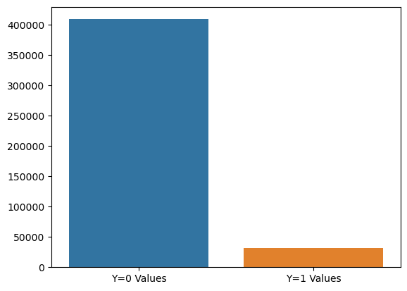

```python
import seaborn as sns

dicty = {}
dicty["Y=0 Values"] = len(clean) - clean.POOR_MENTHLTH.sum()
dicty["Y=1 Values"] = clean.POOR_MENTHLTH.sum()
dat = pd.DataFrame([dicty])
sns.barplot(data = dat)
```

The above visualization tells us the distribution of the target variable POOR_MENTHLTH. From the above, we can see that most of the values of our original dataset had a POOR_MENTHLTH value of 0. This visualization helped us realize that the dataset needed to be undersampled in order to balance our target variable.

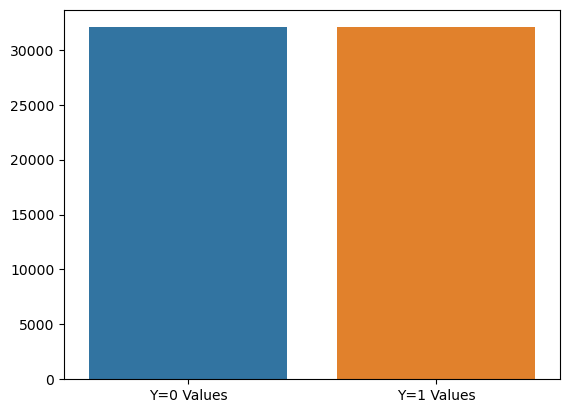

```python
dicty = {}
dicty["Y=0 Values"] = sample.POOR_MENTHLTH.sum()
dicty["Y=1 Values"] = sample.POOR_MENTHLTH.sum()
dat = pd.DataFrame([dicty])
sns.barplot(data = dat)
```

The above visualization is the distribution of our target varaible after we balanced the dataset by undersampling. This helped us be confident in ‘accuracy’ as a good metric to measure our model success.

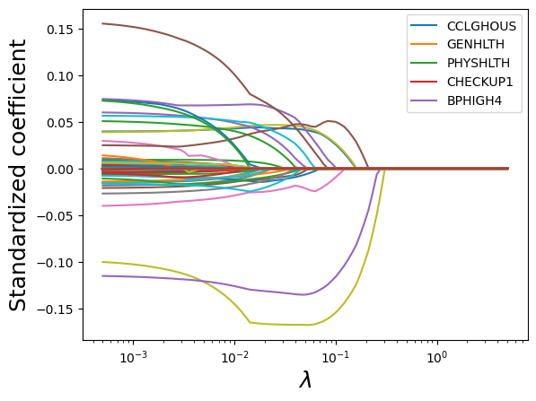

```python
import matplotlib.pyplot as plt
#Visualizing the shrinkage in lasso coefficients with increasing values of the tuning parameter lambda
plt.xlabel('xlabel', fontsize=18)
plt.ylabel('ylabel', fontsize=18)
plt.plot(alphas, coefs)
plt.xscale('log')
plt.xlabel('$\lambda$')
plt.ylabel('Standardized coefficient')
plt.legend(sample.columns[1:6]);
```

The above shows our standardized coefficients relative to our alpha value for our lasso regression. Later we use a lasso regression to see which variables lasso eliminates. This is our main method of feature selection. Our ideal alpha ends up being around 0.00066097.

## 7 Approach

Since this was a classification problem, we developed a logistic model. After we undersampled the rows with 0 for POOR_MENTHLTH, we decided to optimize accuracy. This was because if we could get a model with over 50% accuracy, we knew we were getting somewhere in the regression. By the nature of our topic, it did not seem necessary to prioritize false positives or false negatives, so accuracy seemed like the best metric.

The primary problem we anticipated was the number of variables we had. We knew we could not choose all of them, and we had such a large number (90 variables, but 150 after creating dummies) that we needed an efficient way to select them. At first, we tried to use forward stepwise selection, but we ran into issues getting it to work with a logistic regression. It was also quite computationally expensive to run this selection method.

Our problem did not already have solutions posted anywhere, so we could not build on them.

## 8 Developing the model

Instead of stepwise selection, we decided to use lasso regression to identify the important variables. This is becuase, given our high number of variables, stepwise regression was very computationally expensive. We first standardized the data then ran a for loop to identify the optimal alpha value. Next we ran the lasso regression and used the coefficients to select features.

```python
stats_model.summary()
```

Logit Regression Results

| Dep. Variable: | POOR_MENTHLTH | No. Observations: | 54486 |
| --- | --- | --- | --- |
| Model: | Logit | Df Residuals: | 54423 |
| Method: | MLE | Df Model: | 62 |
| Date: | Mon, 13 Mar 2023 | Pseudo R-squ.: | 0.8073 |
| Time: | 11:34:16 | Log-Likelihood: | -7278.4 |
| converged: | False | LL-Null: | -37767. |
| Covariance Type: | nonrobust | LLR p-value: | 0.000 |

|  | coef | std err | z | P>\|z\| | [0.025 | 0.975] |
| --- | --- | --- | --- | --- | --- | --- |
| PHYSHLTH | 0.0493 | 0.006 | 7.608 | 0.000 | 0.037 | 0.062 |
| MEDCOST | 0.3435 | 0.032 | 10.891 | 0.000 | 0.282 | 0.405 |
| ASTHMA3 | 0.0659 | 0.084 | 0.783 | 0.433 | -0.099 | 0.231 |
| DECIDE | 1.3893 | 0.059 | 23.554 | 0.000 | 1.274 | 1.505 |
| DIFFALON | 0.1562 | 0.103 | 1.515 | 0.130 | -0.046 | 0.358 |
| SMOKE100 | 0.1579 | 0.089 | 1.782 | 0.075 | -0.016 | 0.332 |
| CHILDREN | 0.0198 | 0.024 | 0.818 | 0.413 | -0.028 | 0.067 |
| WEIGHT2 | -0.0003 | 0.001 | -0.339 | 0.734 | -0.002 | 0.001 |
| ALCDAY5 | 0.0059 | 0.004 | 1.673 | 0.094 | -0.001 | 0.013 |
| FRUIT1 | -0.0004 | 0.001 | -0.737 | 0.461 | -0.001 | 0.001 |
| FVBEANS | 0.0009 | 0.002 | 0.458 | 0.647 | -0.003 | 0.005 |
| FVGREEN | 0.0019 | 0.001 | 1.546 | 0.122 | -0.001 | 0.004 |
| FVORANG | -0.0007 | 0.001 | -0.582 | 0.561 | -0.003 | 0.002 |
| _RFDRHV5 | -0.1780 | 0.096 | -1.851 | 0.064 | -0.366 | 0.010 |
| _DRNKWEK | 3.254e-06 | 1.18e-06 | 2.761 | 0.006 | 9.44e-07 | 5.56e-06 |
| _RFBING5 | -0.1836 | 0.078 | -2.367 | 0.018 | -0.336 | -0.032 |
| _SMOKER3 | -0.0623 | 0.018 | -3.410 | 0.001 | -0.098 | -0.026 |
| _AGE80 | -0.0196 | 0.002 | -9.767 | 0.000 | -0.023 | -0.016 |
| _DRDXAR1 | 0.0853 | 0.166 | 0.513 | 0.608 | -0.241 | 0.411 |
| _RFHYPE5 | -12.4560 | nan | nan | nan | nan | nan |
| _RFHLTH | -0.8128 | nan | nan | nan | nan | nan |
| IMONTH_b'02' | -0.2378 | 0.083 | -2.882 | 0.004 | -0.400 | -0.076 |
| CCLGHOUS_Yes | 68.5094 | 1.45e+06 | 4.71e-05 | 1.000 | -2.85e+06 | 2.85e+06 |
| GENHLTH_Excellent | -0.2481 | 0.068 | -3.642 | 0.000 | -0.382 | -0.115 |
| GENHLTH_Fair | -0.1716 | 0.039 | -4.366 | 0.000 | -0.249 | -0.095 |
| GENHLTH_Good | 0.4599 | 0.057 | 8.015 | 0.000 | 0.347 | 0.572 |
| BPHIGH4_NO | -12.4560 | nan | nan | nan | nan | nan |
| BPHIGH4_Yes | -24.8552 | nan | nan | nan | nan | nan |
| SEX_Female | -18.5025 | 1.6e+06 | -1.16e-05 | 1.000 | -3.13e+06 | 3.13e+06 |
| SEX_Male | -18.8087 | 3.88e+05 | -4.85e-05 | 1.000 | -7.6e+05 | 7.59e+05 |
| MARITAL_Married | -0.1806 | 0.042 | -4.328 | 0.000 | -0.262 | -0.099 |
| MARITAL_Separated | 0.3267 | 0.136 | 2.409 | 0.016 | 0.061 | 0.593 |
| EDUCA_some college | 0.0943 | 0.049 | 1.926 | 0.054 | -0.002 | 0.190 |
| EMPLOY1_1 year out of work | 0.3318 | 0.129 | 2.564 | 0.010 | 0.078 | 0.585 |
| EMPLOY1_Employed | -0.0254 | 0.056 | -0.452 | 0.651 | -0.135 | 0.084 |
| EMPLOY1_less than 1 year out of work | 0.4599 | 0.142 | 3.234 | 0.001 | 0.181 | 0.739 |
| EMPLOY1_retired | -0.1350 | 0.070 | -1.937 | 0.053 | -0.272 | 0.002 |
| INCOME2_75,000+ | -0.1371 | 0.057 | -2.420 | 0.016 | -0.248 | -0.026 |
| INCOME2_<10,000 | 0.1208 | 0.088 | 1.379 | 0.168 | -0.051 | 0.292 |
| CRGVLNG1_0.5-2 years | -0.6180 | 0.096 | -6.446 | 0.000 | -0.806 | -0.430 |
| CRGVLNG1_1-6 months | 2.5205 | 0.085 | 29.561 | 0.000 | 2.353 | 2.688 |
| CRGVLNG1_5+ years | 1.9404 | 0.073 | 26.627 | 0.000 | 1.798 | 2.083 |
| CRGVLNG1_<30 days | -0.6289 | 0.098 | -6.420 | 0.000 | -0.821 | -0.437 |
| CRGVHRS1_0-8 hours/week | 0.4580 | 0.060 | 7.595 | 0.000 | 0.340 | 0.576 |
| CRGVHRS1_20-39 hours/week | 0.8534 | 0.091 | 9.421 | 0.000 | 0.676 | 1.031 |
| CRGVHRS1_9-19 hours/week | -1.0993 | 0.098 | -11.249 | 0.000 | -1.291 | -0.908 |
| SCNTMNY1_Never | 0.4950 | 0.088 | 5.601 | 0.000 | 0.322 | 0.668 |
| SCNTMNY1_Rarely | -0.1846 | 0.108 | -1.714 | 0.087 | -0.396 | 0.027 |
| SCNTMNY1_Sometimes | 0.0691 | 0.085 | 0.810 | 0.418 | -0.098 | 0.236 |
| SCNTMNY1_Usually | 1.5803 | 0.096 | 16.447 | 0.000 | 1.392 | 1.769 |
| SCNTMEL1_Always | 1.1769 | 0.093 | 12.643 | 0.000 | 0.994 | 1.359 |
| SCNTMEL1_Never | -0.8377 | 0.071 | -11.828 | 0.000 | -0.977 | -0.699 |
| SCNTMEL1_Rarely | -0.8589 | 0.100 | -8.595 | 0.000 | -1.055 | -0.663 |
| SCNTMEL1_Usually | 1.8514 | 0.101 | 18.246 | 0.000 | 1.653 | 2.050 |
| EMTSUPRT_Always | -3.9625 | 0.117 | -33.953 | 0.000 | -4.191 | -3.734 |
| EMTSUPRT_Never | -2.3214 | 0.208 | -11.147 | 0.000 | -2.730 | -1.913 |
| EMTSUPRT_Rarely | 1.6226 | 0.123 | 13.199 | 0.000 | 1.382 | 1.864 |
| EMTSUPRT_Usually | 0.4752 | 0.094 | 5.059 | 0.000 | 0.291 | 0.659 |
| LSATISFY_Dissatisfied | -0.3627 | 0.101 | -3.602 | 0.000 | -0.560 | -0.165 |
| LSATISFY_Satisfied | -3.3444 | 0.068 | -49.534 | 0.000 | -3.477 | -3.212 |
| LSATISFY_Very dissatisfied | 4.2628 | 0.135 | 31.565 | 0.000 | 3.998 | 4.528 |
| _LMTSCL1_Not told they have arthritis | -0.0987 | 0.165 | -0.598 | 0.550 | -0.422 | 0.225 |
| _PASTAE1_Did Not Meet Both Guidelines | -24.8601 | nan | nan | nan | nan | nan |
| _PASTAE1_Met Both Guidelines | -12.4511 | 3.93e+15 | -3.17e-15 | 1.000 | -7.71e+15 | 7.71e+15 |
| _PAREC1_Did not meet Either Guideline | 0.0027 | 0.050 | 0.054 | 0.957 | -0.095 | 0.100 |
| _PAREC1_Met Both Guidelines | -12.4511 | 3.89e+15 | -3.2e-15 | 1.000 | -7.62e+15 | 7.62e+15 |
| _PACAT1_Inactive | 0.1772 | 0 | inf | 0.000 | 0.177 | 0.177 |

## 9 Limitations of the model with regard to inference / prediction

Since our model attempts a mix of inference and prediction, we will provide answers to both parts.

The data our model is based on is from 2015, from a nation-wide telephone survey about Americans’ health. Although our model is using data from 8 years ago, we acknowledged that health trends do not change drastically in that period of time to the point where it invalidates the usefulness of our model. Thus, our model is relatively relevant and useful for observing mental health in Americans in this year. Since our model is based on nation-wide data, it is also acceptable to generalize our model to the general American population. However, we recommend caution when thinking about applying our model to very specific, specialized groups that have qualities that are not included in our list of predictor variables. Because our mdoel is generalized from the average American, it would be faulty to take our model and apply it to such a unique group that have shared characteristics that our model does not cover. In this case, our model would not be able to predict well because there may be other variables that are unexplained by our model. Still, overall, our model remains relevant and useful for the average American for inference.

As for prediction, it is definitely possible for stakeholders to collect data relating to the predictors in our model. It is not difficult to obtain data required for our model, as our model can operate with survey-style data about people’s lifestyles and mental health. The prediction can be done right away, as we have access to the predictor variables and the outcome variable is determined by observing if the individual currently has depression. Thus, the prediction can be done instantly as we just need the survey results. However, if one wanted to predict how current lifestyle qualities affect the development of depression later, then it would require at least a few years to let depression possibly develop (or not develop).

## 10 Conclusions and Recommendations to stakeholder(s)

We also found that financial situation is another category that influences mental health. Variables indicating financial stress in regards to being unemployed, low income, and being unable to afford nutritious meals all were positively associated with depression. This suggests that financial burdens are not just about being able to afford physical goods, but they also have a big toll on mental health as well. We observed that financial stress may lead to other situations that can combine to result in worse mental health, such as being unable to afford nutritious meals that are good for mental health.

## GitHub and individual contribution

Put the **Github link** for the project repository.

https://github.com/fyre87/TeamTeam_Stat303

Add details of each team member’s contribution in the table below.

## Individual contribution

| Team member | Contributed aspects | Details | Number of GitHub commits |
| --- | --- | --- | --- |
| Will Pattie | Data cleaning and EDA | Cleaned data to impute missing values and developed visualizations to identify appropriate variable transformations. | 9 |
| Margaret Pirozzolo | Feature selection and model development | Used Lasso to select features. Ran the model using those features. | 7 |
| Lena Choe | Data cleaning and model interpretation | Cleanded data and interpreted our model for use of stakeholders. | 8 |
| Matt Weiss | Data Cleaning | Cleaned data and researched the dataset. | 6 |

List the **challenges** you faced when collaborating with the team on GitHub. Are you comfortable using GitHub? Do you feel GitHuB made collaboration easier? If not, then why? *(Individual team members can put their opinion separately, if different from the rest of the team)*

We all started off with little to no knowledge of github, but found that once we figued out how to commit and download, it was fairly straightforward. It did help make collaboration easier since committing to a centeral hub is easier than emailing all of our files back and forth.

## References

[1] CDC, 2015. Behavioral Risk Factor Surveillance System, https://www.cdc.gov/brfss/annual_data/annual_2015.html.

## Appendix

In order to show the tabular form of each variable using code, we inputted the data cleaning code here:

```python
import pandas as pd
import numpy as np

brfss = pd.read_csv('2015.csv')
clean = brfss.copy()

variables = ['_STATE','IMONTH','NUMADULT','CCLGHOUS','GENHLTH','PHYSHLTH','CHECKUP1',
             'BPHIGH4','DIABETE3','HLTHPLN1','MEDCOST','TOLDHI2','CVDINFR4','ASTHMA3','CHCSCNCR',
           'CHCOCNCR','ADDEPEV2','VETERAN3','DECIDE','DIFFALON','SMOKE100','SEX','MARITAL','EDUCA',
             'EMPLOY1','CHILDREN','INCOME2','WEIGHT2','ALCDAY5','FRUIT1',
             "FVBEANS", "FVGREEN", "FVORANG", "VEGETAB1",
             "EXERANY2", "EXEROFT1", "STRENGTH", "LMTJOIN3", "ARTHDIS2",
            "JOINPAIN", "PREDIAB1", "CAREGIV1", "CRGVLNG1", "CRGVHRS1", "CIMEMLOS", "DRADVISE",
             'SCNTMNY1', 'SCNTMEL1','SCNTWRK1','SXORIENT','TRNSGNDR','EMTSUPRT', 'LSATISFY',
             'ADPLEASR', 'ADSLEEP', 'ADENERGY', 'ADEAT1','ADFAIL','ADTHINK','MISTMNT','ADANXEV',
            '_LMTSCL1', '_LMTWRK1', '_LMTACT1', '_PASTAE1',
             '_PAREC1', '_PA300R2', '_PA150R2', '_PAINDX1', '_PACAT1', 'PA1MIN_', '_TOTINDA',
             '_VEG23', '_VEGESUM', '_FRTLT1', '_VEGLT1','_FRUTSUM', '_RFDRHV5', '_DRNKWEK',
             '_RFBING5', '_SMOKER3', '_INCOMG', '_BMI5CAT', '_AGE80', '_DRDXAR1',
             '_RFHYPE5', '_RFHLTH', '_PASTRNG']


data = brfss.loc[:, variables]
clean = data.copy()
clean.head()

value_map = {1.0: 'Alabama',2.0: 'Alaska', 4.0: 'Arizona', 5.0: 'Arkansas', 6.0: 'California', 8.0: 'Colorado',
             9.0: 'Connecticut', 10.0: 'Delaware', 11.0: 'District of Columbia', 12.0: 'Florida', 13.0: 'Georgia',
             15.0: 'Hawaii', 16.0: 'Idaho', 17.0: 'Illinois', 18.0: 'Indiana', 19.0: 'Iowa', 20.0: 'Kansas',
             21.0: 'Kentucky',22.0: 'Louisiana',23.0: 'Maine' ,24.0: 'Maryland',25.0: 'Massachusetts',
             26.0: 'Michigan' ,27.0: 'Minnesota',28.0: 'Mississippi',29.0: 'Missouri',30.0: 'Montana',
             31.0: 'Nebraska' ,32.0: 'Nevada'  ,33.0: 'New Hampshire' ,34.0: 'New Jersey' ,35.0: 'New Mexico',
             36.0: 'New York' ,37.0: 'North Carolina' ,38.0: 'North Dakota',39.0: 'Ohio'  ,40.0: 'Oklahoma',
             41.0: 'Oregon',42.0: 'Pennsylvania',44.0: 'Rhode Island',45.0: 'South Carolina',46.0: 'South Dakota',
             47.0: 'Tennessee',48.0: 'Texas',49.0: 'Utah',50.0: 'Vermont',51.0: 'Virginia',53.0: 'Washington',
             54.0: 'West Virginia',55.0: 'Wisconsin',56.0: 'Wyoming',66.0: 'Guam',72.0: 'Puerto Rico'}
clean['_STATE'] = clean['_STATE'].replace(value_map)

value_map = {b'01': 'January', b'02': 'February', b'03': 'March', b'04': 'April', b'05':'May',b'06':'June',
             b'07':'July',b'08':'August',b'09': 'Spetember', b'10':'Ocetober',b'11':'November',b'12':'December'}

clean['IMONTH'] = clean['IMONTH'].replace(value_map)

clean.loc[(clean.NUMADULT == 'BLANK'),'NUMADULT']= np.nan

value_map = {1.0: 'Yes', 'BLANK':'No'}
clean['CCLGHOUS'] = clean['CCLGHOUS'].replace(value_map)

value_map = {1.0: 'Excellent', 2.0: 'Very Good', 3.0: 'Good', 4.0: 'Fair', 5.0:'Poor',6.0: np.nan,
             7.0: np.nan ,8.0: np.nan}
clean['GENHLTH'] = clean['GENHLTH'].replace(value_map)

clean.loc[(clean.PHYSHLTH == 77),'PHYSHLTH']= np.nan
clean.loc[(clean.PHYSHLTH == 99),'PHYSHLTH']= np.nan
clean.loc[(clean.PHYSHLTH == 88),'PHYSHLTH']=0

value_map = {1.0: 'One year', 2.0: 'Two years', 3.0: 'Five years', 4.0: 'over five',
             7.0:np.nan,8.0:'Never',9.0: np.nan, 'BLANK':np.nan}

clean['CHECKUP1'] = clean['CHECKUP1'].replace(value_map)


value_map = {1.0: 'Yes', 2.0: 'NO', 3.0:'NO', 4.0:'NO',7.0:np.nan, 9.0: np.nan, 'BLANK':np.nan}

clean['BPHIGH4'] = clean['BPHIGH4'].replace(value_map)

value_map = {1.0: 'Yes', 2.0: 'NO', 3.0:'NO', 4.0:'NO',7.0:np.nan, 9.0: np.nan, 'BLANK':np.nan}

clean['DIABETE3'] = clean['DIABETE3'].replace(value_map)

var_list = ['HLTHPLN1','MEDCOST','TOLDHI2','CVDINFR4','ASTHMA3','CHCSCNCR',
           'CHCOCNCR','ADDEPEV2','VETERAN3','DECIDE','DIFFALON','SMOKE100']

for var in var_list:

    value_map = {1.0: 1, 2.0: 0, 7.0:np.nan, 9.0: np.nan, 'BLANK':np.nan}

    clean[var] = clean[var].replace(value_map)


value_map = {1.0: 'Male', 2.0: 'Female'}
clean['SEX'] = clean['SEX'].replace(value_map)

value_map = {1.0: 'Married', 2.0: 'Divorces', 3.0: 'Widowed', 4.0: 'Separated', 5.0:'Never Married',6.0:'Unmarried Couple',
             9.0: 'Refused'}

clean['MARITAL'] = clean['MARITAL'].replace(value_map)

value_map = {1.0: 'None', 2.0: 'primary', 3.0: 'some secondary', 4.0: 'secondary', 5.0:'some college',6.0:'college',
             9.0: 'Refused'}

clean['EDUCA'] = clean['EDUCA'].replace(value_map)

value_map = {1.0: 'Employed', 2.0: 'Self-Employed', 3.0: '1 year out of work', 4.0: 'less than 1 year out of work', 5.0:'homemaker',6.0:'student',
             7.0:'retired',8.0:'unable to work',9.0: np.nan}

clean['EMPLOY1'] = clean['EMPLOY1'].replace(value_map)

clean.loc[(clean.CHILDREN == 'BLANK'),'CHILDREN']= np.nan
clean.loc[(clean.CHILDREN == 99),'CHILDREN']= np.nan
clean.loc[(clean.CHILDREN == 88),'CHILDREN']=0

value_map = {1.0: '<10,000', 2.0: '<15,000', 3.0: '<20,000', 4.0: '<25,000', 5.0:'<35,000',6.0:'<50,000',
             7.0:'<75,000',8.0:'75,000+',77.0: np.nan, 99.0:np.nan,'BLANK':np.nan}

clean['INCOME2'] = clean['INCOME2'].replace(value_map)

clean.loc[(clean.WEIGHT2 == 'BLANK'),'WEIGHT2']= np.nan
clean.loc[(clean.WEIGHT2 == 7777),'WEIGHT2']= np.nan
clean.loc[(clean.WEIGHT2 == 9999),'WEIGHT2']=np.nan

clean['WEIGHT2'] = np.where((clean['WEIGHT2'] >= 9000),
                               np.mod(clean['WEIGHT2'], 9000)*2.2, clean['WEIGHT2'])


clean.loc[(clean.ALCDAY5 == 'BLANK'),'ALCDAY5']= np.nan
clean.loc[(clean.ALCDAY5 == 777),'ALCDAY5']= np.nan
clean.loc[(clean.ALCDAY5 == 999),'ALCDAY5']=np.nan
clean.loc[(clean.ALCDAY5 == 888),'ALCDAY5']=0

#making it all within the last month

clean['ALCDAY5'] = np.where((clean['ALCDAY5'] <= 200),
                               np.mod(clean['ALCDAY5'], 100)*4, clean['ALCDAY5'])
clean['ALCDAY5'] = np.where((clean['ALCDAY5'] >= 200),
                               np.mod(clean['ALCDAY5'], 200), clean['ALCDAY5'])
```

```python
clean.loc[(clean.FRUIT1 == 'BLANK'),'FRUIT1']= np.nan
clean.loc[(clean.FRUIT1 == 777),'FRUIT1']= np.nan
clean.loc[(clean.FRUIT1 == 999),'FRUIT1']=np.nan
clean.loc[(clean.FRUIT1 == 555),'FRUIT1']=0
clean.loc[(clean.FRUIT1 == 300),'FRUIT1']=0

#making it all within the last month
clean['FRUIT1'] = np.where((clean['FRUIT1'] <= 200),
                               np.mod(clean['FRUIT1'], 100)*30, clean['FRUIT1'])
clean['FRUIT1'] = np.where((clean['FRUIT1'] >= 200)&(clean['FRUIT1'] < 300),
                               np.mod(clean['FRUIT1'], 200)*4, clean['FRUIT1'])
clean['FRUIT1'] = np.where((clean['FRUIT1'] > 300)&(clean['FRUIT1'] < 400),
                               np.mod(clean['FRUIT1'], 300), clean['FRUIT1'])

#Numeric with 100 daily 200 weekly 300 monthly
numlist = ["FVBEANS", "FVGREEN", "FVORANG", "VEGETAB1"]
for var in numlist:
    clean[var] = np.where((data[var] >= 100) & (data[var] <= 199),
                               np.mod(data[var], 100)*30, clean[var])
    clean[var] = np.where((data[var] >= 200) & (data[var] <= 299),
                               np.mod(data[var], 200)*4, clean[var])
    clean[var] = np.where((data[var] >= 300) & (data[var] <= 399),
                               np.mod(data[var], 300), clean[var])
    clean[var] = np.where(data[var] == 555, 0, clean[var])
    clean[var] = np.where(data[var] == 777, np.nan, clean[var])
    clean[var] = np.where(data[var] == 999, np.nan, clean[var])

#Numeric but 100+ is weekly 200+ is monthly
numlist2 = ["EXEROFT1", "STRENGTH"]
for var in numlist2:
    clean[var] = np.where((data[var] >= 100) & (data[var] <= 199),
                               np.mod(data[var], 100)*4, clean[var])
    clean[var] = np.where((data[var] >= 200) & (data[var] <= 299),
                               np.mod(data[var], 200), clean[var])
    clean[var] = np.where(data[var] == 777, np.nan, clean[var])
    clean[var] = np.where(data[var] == 888, 0, clean[var])
    clean[var] = np.where(data[var] == 999, np.nan, clean[var])

#Binary vars
binarylist = ["EXERANY2", "LMTJOIN3", "ARTHDIS2", "CIMEMLOS", "DRADVISE"]
for var in binarylist:
    clean[var] = np.where(data[var] == 2, 0, clean[var])
    clean[var] = np.where(data[var] == 7, np.nan, clean[var])
    clean[var] = np.where(data[var] == 9, np.nan, clean[var])

#1-10 vars
list1_10 = ["JOINPAIN"]
for var in list1_10:
    clean[var] = np.where(data[var] == 7, np.nan, clean[var])
    clean[var] = np.where(data[var] == 9, np.nan, clean[var])

#yes, yes during pregnancy, and no. Convert to binary
almost_binarylist = ["PREDIAB1"]
for var in almost_binarylist:
    clean[var] = np.where(data[var] == 2, 1, clean[var])
    clean[var] = np.where(data[var] == 3, 0, clean[var])
    clean[var] = np.where(data[var] == 7, np.nan, clean[var])
    clean[var] = np.where(data[var] == 9, np.nan, clean[var])


almost_binarylist2 = ["CAREGIV1"]
for var in almost_binarylist2:
    clean[var] = np.where(data[var] == 7, np.nan, clean[var])
    clean[var] = np.where(data[var] == 8, 1, clean[var]) #Died
    clean[var] = np.where(data[var] == 9, np.nan, clean[var])

CRGVLNG1_map = {1.0: '<30 days', 2.0: '1-6 months', 3.0: '0.5-2 years', 4.0: '2-5 years', 5.0: '5+ years'}
clean["CRGVLNG1"] = clean["CRGVLNG1"].replace(CRGVLNG1_map)
clean["CRGVLNG1"] = np.where(data["CRGVLNG1"] == 7, np.nan, clean["CRGVLNG1"])
clean["CRGVLNG1"] = np.where(data["CRGVLNG1"] == 9, np.nan, clean["CRGVLNG1"])

CRGVHRS1_map = {1.0: '0-8 hours/week', 2.0: '9-19 hours/week', 3.0: '20-39 hours/week', 4.0: '40+ hours/week'}
clean["CRGVHRS1"] = clean["CRGVHRS1"].replace(CRGVHRS1_map)
clean["CRGVHRS1"] = np.where(data["CRGVHRS1"] == 7, np.nan, clean["CRGVHRS1"])
clean["CRGVHRS1"] = np.where(data["CRGVHRS1"] == 9, np.nan, clean["CRGVHRS1"])

values = {1: 'Always',
          2: 'Usually',
          3: 'Sometimes',
          4: 'Rarely',
          5: 'Never',
          7: np.nan,
          8: np.nan,
          9: np.nan
         }

clean['SCNTMNY1'] = clean['SCNTMNY1'].replace(values)

values = {1: 'Always',
          2: 'Usually',
          3: 'Sometimes',
          4: 'Rarely',
          5: 'Never',
          7: np.nan,
          8: np.nan,
          9: np.nan
         }

clean['SCNTMEL1'] = clean['SCNTMEL1'].replace(values)

values = {97 : np.nan,
          98 : np.nan,
          99 : np.nan}

clean['SCNTWRK1'] = clean['SCNTWRK1'].replace(values)

values = {1: 'Straight',
          2: 'Lesbian or gay',
          3: 'Bisexual',
          4: 'Other',
          7: np.nan,
          9: np.nan
         }

clean['SXORIENT'] = clean['SXORIENT'].replace(values)

values = {1: 'Yes, Transgender, male-to-female',
          2: 'Yes, Transgender, female to male',
          3: 'Yes, Transgender, gender nonconforming',
          4: 'No',
          7: np.nan,
          9: np.nan
         }

clean['TRNSGNDR'] = clean['TRNSGNDR'].replace(values)

values = {1: 'Always',
          2: 'Usually',
          3: 'Sometimes',
          4: 'Rarely',
          5: 'Never',
          7: np.nan,
          9: np.nan
         }

clean['EMTSUPRT'] = clean['EMTSUPRT'].replace(values)

values = {1: 'Very satisfied',
          2: 'Satisfied',
          3: 'Dissatisfied',
          4: 'Very dissatisfied',
          7: np.nan,
          9: np.nan
         }

clean['LSATISFY'] = clean['LSATISFY'].replace(values)

values = {88: np.nan,
          99: np.nan,
          77: np.nan
         }

clean['ADPLEASR'] = clean['ADPLEASR'].replace(values)

values = {88: np.nan,
          99: np.nan,
          77: np.nan
         }

clean['ADSLEEP'] = clean['ADSLEEP'].replace(values)

values = {88: np.nan,
          99: np.nan,
          77: np.nan
         }

clean['ADENERGY'] = clean['ADENERGY'].replace(values)

values = {88: np.nan,
          99: np.nan,
          77: np.nan
         }

clean['ADEAT1'] = clean['ADEAT1'].replace(values)

values = {88: np.nan,
          99: np.nan,
          77: np.nan
         }

clean['ADFAIL'] = clean['ADFAIL'].replace(values)

values = {88: np.nan,
          99: np.nan,
          77: np.nan
         }
```

```python
clean['ADTHINK'] = clean['ADTHINK'].replace(values)

values = {1: 1,
          2 : 0,
          7: np.nan,
          9: np.nan
         }

clean['MISTMNT'] = clean['MISTMNT'].replace(values)

values = {1: 1,
          2 : 0,
          7: np.nan,
          9: np.nan
         }

clean['ADANXEV'] = clean['ADANXEV'].replace(values)

value_map = {1.0: 'Told have arthritis and have limited usual activities',
             2.0: 'Told have arthritis and no limited usual activities',
             3.0: 'Not told they have arthritis',
             9.0: np.nan}

clean['_LMTACT1'] = clean['_LMTACT1'].replace(value_map)


limited_social = {1.0: 'Told have arthritis and social activities limited a lot',
             2.0: 'Told have arthritis and social activities limited a little',
             3.0: 'Told have arthritis and social activities not limited',
             4.0: 'Not told they have arthritis',
             9.0: np.nan}

clean['_LMTSCL1'] = clean['_LMTSCL1'].replace(limited_social)


limited_work = {1.0: 'Told have arthritis and have limited work',
             2.0: 'Told have arthritis and no limited work',
             3.0: 'Not told they have arthritis',
             9.0: np.nan}

work_out = {1.0: '150+ minutes (or vigorous equivalent minutes) of physical activity',
             2.0: '1-149 minutes (or vigorous equivalent minutes) of physical',
             3.0: '0 minutes',
             9.0: np.nan}

clean['_PA150R2'] = clean['_PA150R2'].replace(limited_work)


clean['_LMTWRK1'] = clean['_LMTWRK1'].replace(limited_work)


aerobic_strength = {1.0: 'Met Both Guidelines',
             2.0: 'Did Not Meet Both Guidelines',
             9.0: np.nan}

clean['_PASTAE1'] = clean['_PASTAE1'].replace(aerobic_strength)


strength_dos = {1.0: 'Met Both Guidelines',
             2.0: 'Met Aerobic Guidelines Only',
             3.0: ' Met Strenghtening Guidelines Only',
             4.0: 'Did not meet Either Guideline',
             9.0: np.nan}

clean['_PAREC1'] = clean['_PAREC1'].replace(strength_dos)


phys_act = {1.0: 'Highly Active',
             2.0: 'Active',
             3.0: 'Insufficiently Active',
             4.0: 'Inactive',
             9.0: np.nan}

clean['_PACAT1'] = clean['_PACAT1'].replace(phys_act)

binarylist = ["_PASTRNG", "_PAINDX1", "_PASTRNG", "_TOTINDA", "_VEGLT1", "_FRTLT1", "_RFDRHV5", "_RFBING5", "_RFHYPE5", "_RFHLTH", "_DRDXAR1"]
for var in binarylist:
    clean[var] = np.where(clean[var] == 2, 0, clean[var])
    clean[var] = np.where(clean[var] == 7, np.nan, clean[var])
    clean[var] = np.where(clean[var] == 9, np.nan, clean[var])

weight = {1.0: 'under weight',
               2.0: 'normal weight',
               3.0: 'overweight',
               4.0: 'obese'}

clean['_BMI5CAT'] = clean['_BMI5CAT'].replace(weight)


# replacing 88 with 0 because 88 means none (codebook)
brfss.loc[(brfss.MENTHLTH == 88),'MENTHLTH']=0

# replacing 77 and 99 with NA (codebook)
brfss.loc[(brfss.MENTHLTH == 77),'MENTHLTH']= pd.NA
brfss.loc[(brfss.MENTHLTH == 99),'MENTHLTH']= pd.NA

brfss['MENTHLTH']

# finding 2 standard deviations above the mean
brfss['MENTHLTH'].mean() + (2*(brfss['MENTHLTH'].std()))

# create new column with the people above 2 sd above the mean calssified as poor mental health,
# and all others classified as not
clean['POOR_MENTHLTH'] = brfss['MENTHLTH']


clean.loc[(clean.POOR_MENTHLTH <= 18.5),'POOR_MENTHLTH']=0
clean.loc[(clean.POOR_MENTHLTH >= 18.0),'POOR_MENTHLTH']=1

clean['POOR_MENTHLTH'].sum() / len(clean['POOR_MENTHLTH'])

#Concat all the poor mental health people with a random sample of not poor mental health people
#Combine them together, should be 50% poor mental health and 50% not poor mental health
sample = pd.concat([clean.loc[clean.POOR_MENTHLTH == 0, :].sample(
    n=clean['POOR_MENTHLTH'].sum(), replace = False, random_state=50), clean.loc[clean.POOR_MENTHLTH == 1, :]], axis=0)


#Dropping these variables because they are basically depression
sample = sample.drop(["ADDEPEV2", "MISTMNT"], axis = 1)


sample.POOR_MENTHLTH = sample.POOR_MENTHLTH.astype(int)
```

```python
# Margaret Pirozzolo
# dropping the columns with a lot of missing data
dropy = ["_STATE","NUMADULT", "TOLDHI2", "VEGETAB1", "EXEROFT1", "STRENGTH", "LMTJOIN3", "ARTHDIS2", "JOINPAIN", "PREDIAB1", "CAREGIV1", "CIMEMLOS", "DRADVISE", "SCNTWRK1", "ADPLEASR", "ADSLEEP", "ADENERGY", "ADEAT1", "ADFAIL", "ADTHINK", "ADANXEV", "_PAINDX1", "PA1MIN_", "_VEGESUM", "_FRTLT1", "_VEGLT1", "_FRUTSUM", "_PASTRNG"]
sample = sample.drop(dropy, axis = 1)
# imputing the missing values naively
sample = sample.fillna(method = 'ffill')


from sklearn.model_selection import train_test_split
X_train, X_test, y_train, y_test = train_test_split(
    sample.drop("POOR_MENTHLTH", axis=1),
    sample.POOR_MENTHLTH,
    test_size=0.15,
    random_state=50)

def dummies_from_objects(x):
    x = x.drop(x.select_dtypes(include=['float', 'int64']).columns, axis=1)
    dummy = pd.DataFrame()
    for var1 in range(0, len(x.columns)):
        dat = pd.get_dummies(x.iloc[:, var1], prefix=x.columns[var1])
        dummy = pd.concat([dummy, dat], axis = 1)
    return dummy

X_train_dummy = pd.concat([X_train, dummies_from_objects(X_train)], axis = 1)
X_train_dummy = X_train_dummy.drop(X_train_dummy.select_dtypes(include=['object']).columns, axis=1)

X_test_dummy = pd.concat([X_test, dummies_from_objects(X_test)], axis = 1)
X_test_dummy = X_test_dummy.drop(X_test_dummy.select_dtypes(include=['object']).columns, axis=1)

# Margaret Pirozzolo
# Standardizing the dataset for Lasso

from sklearn.preprocessing import StandardScaler
from sklearn.linear_model import Ridge, RidgeCV, Lasso, LassoCV
#standardizing the variables
scaler = StandardScaler()
scaler.fit(X_train_dummy)
Xstd = scaler.transform(X_train_dummy)

import statsmodels.formula.api as sm

#Function to compute confusion matrix and prediction accuracy on training data
def confusion_matrix_train(model,cutoff=0.5):
    # Confusion matrix
    cm_df = pd.DataFrame(model.pred_table(threshold = cutoff))
    # Formatting the confusion matrix
    cm_df.columns = ['Predicted 0', 'Predicted 1']
    cm_df = cm_df.rename(index={0: 'Actual 0',1: 'Actual 1'})
    cm = np.array(cm_df)
    # Calculate the accuracy
    accuracy = (cm[0,0]+cm[1,1])/cm.sum()
    sns.heatmap(cm_df, annot=True, cmap='Blues', fmt='g')
    plt.ylabel("Actual Values")
    plt.xlabel("Predicted Values")
    print("Classification accuracy = {:.1%}".format(accuracy))

#Function to compute confusion matrix and prediction accuracy on test data
def confusion_matrix_test(data,actual_values,model,cutoff=0.5):
    # Predict the values using the Logit model
    pred_values = model.predict(data)
    # Specify the bins
    bins=np.array([0,cutoff,1])
    # Confusion matrix
    cm = np.histogram2d(actual_values, pred_values, bins=bins)[0]
    cm_df = pd.DataFrame(cm)
    cm_df.columns = ['Predicted 0','Predicted 1']
    cm_df = cm_df.rename(index={0: 'Actual 0',1:'Actual 1'})
    accuracy = (cm[0,0]+cm[1,1])/cm.sum()
    sns.heatmap(cm_df, annot=True, cmap='Blues', fmt='g')
    plt.ylabel("Actual Values")
    plt.xlabel("Predicted Values")
    print("Classification accuracy = {:.1%}".format(accuracy))

#Tests 100 cutoff accuracies and returns the accuracy at each one
def cutoff_accuracy(model):
    accuracy = []
    for i in range(0, 100):

        # Confusion matrix
        cutoff = i/100
        cm_df = pd.DataFrame(model.pred_table(threshold = cutoff))
        cm = np.array(cm_df)
        accuracy.append((cm[0,0]+cm[1,1])/cm.sum())
    return pd.DataFrame(accuracy)

#Get the highest value in that frame
def get_accuracy(model):
    accuracy = (cutoff_accuracy(model).max())[0]
    return accuracy

alphas = 10**np.linspace(1,-3,100)*0.5
lasso = Lasso(max_iter = 10000)
coefs = []

for a in alphas:
    lasso.set_params(alpha=a)
    lasso.fit(Xstd, y_train)
    coefs.append(lasso.coef_)

lassocv = LassoCV(alphas = alphas, cv = 10, max_iter = 100000)
lassocv.fit(Xstd, y_train)

#Optimal value of the tuning parameter - lamda
lassocv.alpha_


lasso = Lasso(alpha =  0.0006609705742330143)
lasso.fit(Xstd, y_train)

import numpy as np
from sklearn.linear_model import Lasso
from sklearn.feature_selection import SelectFromModel

sel_ = SelectFromModel(Lasso(alpha=0.0006609705742330143))
sel_.fit(np.array(X_train_dummy), y_train)

# make a list with the selected features and print the outputs
selected_features = X_train_dummy.columns[(sel_.get_support())]

print('total features: {}'.format((X_train_dummy.shape[1])))
print('selected features: {}'.format(len(selected_features)))
print('features with coefficients shrank to zero: {}'.format(
    np.sum(sel_.estimator_.coef_ == 0)))


variables = dict(zip(X_train_dummy.columns, sel_.estimator_.coef_))

variable_list = [k for k,v in variables.items() if float(v) != 0]

X_train_smaller = X_train_dummy.loc[:,variable_list]
X_test_smaller = X_test_dummy.loc[:,variable_list]

# using all those features for a model
import statsmodels.api as sm
stats_model = sm.Logit(y_train, X_train_smaller).fit()
```

```
total features: 154
selected features: 62
features with coefficients shrank to zero: 87
Warning: Maximum number of iterations has been exceeded.
         Current function value: 0.133583
         Iterations: 35
```